# Assignment: Esoph and Young People Survey

Çağatay Nüfer

12 09 2020

# The Esoph Data

```r
library(tidyverse)
library(ggplot2)
library(data.table)
library(dplyr)
library(ggthemes)
library(ggpubr)
```

Glimpse, and the summary of the data is available in the code below.

```r
data<-data.frame()
data<-esoph

glimpse(esoph)
```

```
## Rows: 88
## Columns: 5
## $ agegp     <ord> 25-34, 25-34, 25-34, 25-34, 25-34, 25-34, 25-34, 25-34, 2...
## $ alcgp     <ord> 0-39g/day, 0-39g/day, 0-39g/day, 0-39g/day, 40-79, 40-79,...
## $ tobgp     <ord> 0-9g/day, 10-19, 20-29, 30+, 0-9g/day, 10-19, 20-29, 30+,...
## $ ncases    <dbl> 0, 0, 0, 0, 0, 0, 0, 0, 0, 0, 0, 0, 1, 0, 0, 0, 1, 0, 0, ...
## $ ncontrols <dbl> 40, 10, 6, 5, 27, 7, 4, 7, 2, 1, 2, 1, 1, 1, 2, 60, 14, 7...
```

```r
summary(esoph)
```

```
##    agegp          alcgp         tobgp        ncases         ncontrols
##  25-34:15   0-39g/day:23   0-9g/day:24   Min.   : 0.000   Min.   : 1.00
##  35-44:15   40-79    :23   10-19   :24   1st Qu.: 0.000   1st Qu.: 3.00
##  45-54:16   80-119   :21   20-29   :20   Median : 1.000   Median : 6.00
##  55-64:16   120+     :21   30+     :20   Mean   : 2.273   Mean   :11.08
##  65-74:15                                3rd Qu.: 4.000   3rd Qu.:14.00
##  75+  :11                                Max.   :17.000   Max.   :60.00
```

Renaming the columns,

```r
colnames(esoph)[1]  <- "Age"
colnames(esoph)[2]  <- "Alcohol"
colnames(esoph)[3]  <- "Tobacco"
```

### Data Analysis

Factors in the data are grouped by other factors among the data to visually inspect the relation between the percentage of cancer cases.ncounts is divided by ncontrols to compute the percentage.

```r
esoph<- esoph %>% group_by(Age)%>% mutate(total_casesA= sum(ncases),total_controlA=sum(ncontrols),age_group= 100*(ncases/ncontrols))
esoph<- esoph %>% group_by(Alcohol)%>% mutate(total_casesAl= sum(ncases),total_controlAl=sum(ncontrols),alcohol_group= 100*(ncases/ncontrols))
esoph<- esoph %>% group_by(Tobacco)%>% mutate(total_casesT= sum(ncases),total_controlT=sum(ncontrols),tobacco_group= 100*(ncases/ncontrols))
```

In the graph, the age groups 55-64 and 65-74 are the top tier in case of cancer percentage. The age groups 25-34 and 35-44 have significantly lower percentages.

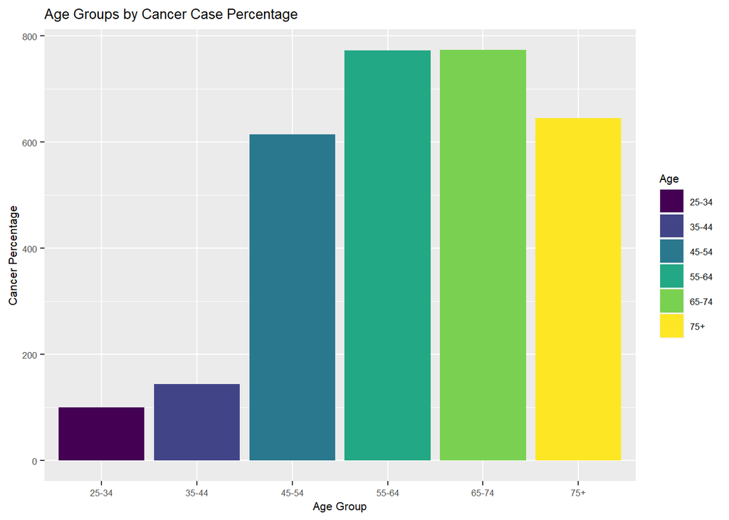

```r
ggplot(esoph)+
  geom_bar(aes(Age,age_group,fill=Age), stat="identity")+
  labs(title="Age Groups by Cancer Case Percentage",x="Age Group",y="Cancer Percentage")+
  theme(text=element_text(size=8))
```

In the graph, tobacco consumption of 30g+ is the top tier in case of cancer percentage. The result is unexpected as it’s acknowledged that higher tobacco consumption has a higher risk of cancer but the results are not as proportional.

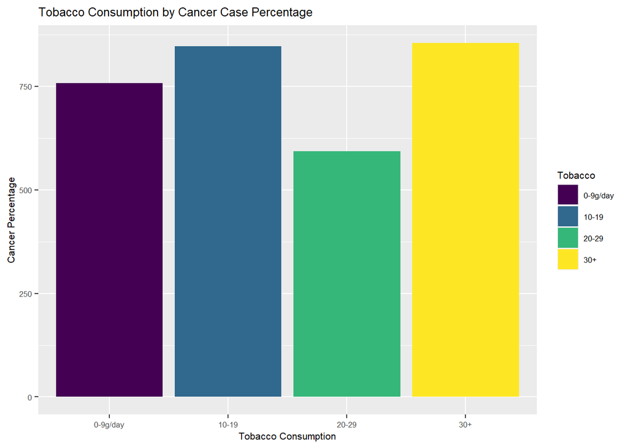

```r
ggplot(esoph)+
  geom_bar(aes(Tobacco,tobacco_group,fill=Tobacco), stat="identity")+
  labs(title="Tobacco Consumption by Cancer Case Percentage",x="Tobacco Consumption",y="Cancer Percentage")+
  theme(text=element_text(size=8))
```

In the graph, 120g+ consumption of alcohol is the top tier in case of cancer percentage. From the graph, there seems to be a significance to cancer percentage as the cancer percentage seems proportional to the alcohol consumption.

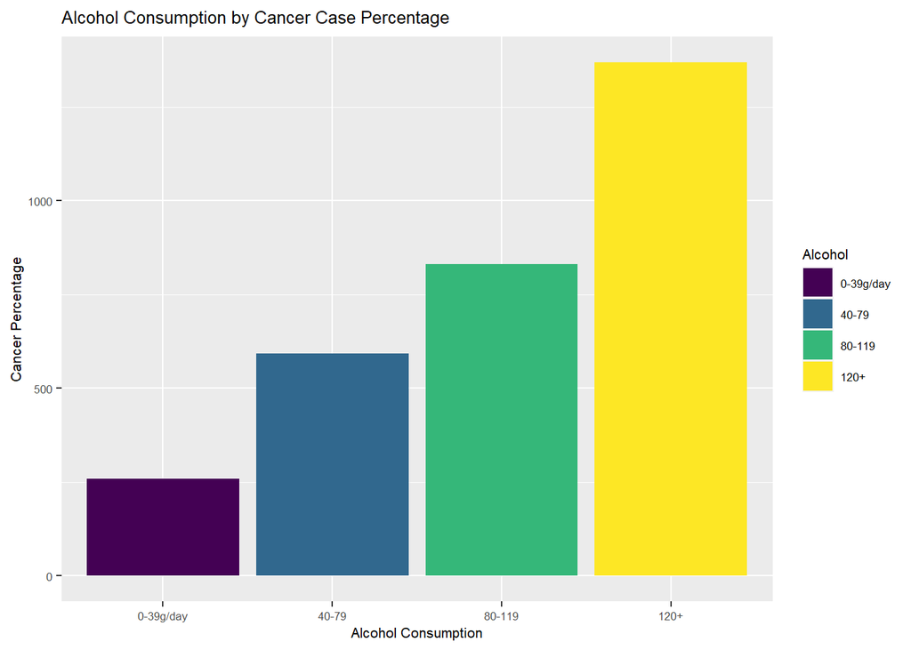

```r
ggplot(esoph)+
  geom_bar(aes(Alcohol,alcohol_group,fill=Alcohol), stat="identity")+
  labs(title="Alcohol Consumption by Cancer Case Percentage",x="Alcohol Consumption",y="Cancer Percentage")+
  theme(text=element_text(size=8))
```

To see the relation between the factors more vividly, faceting is used for the next graphs. After grouping the factors and faceting the graph, the cancer case percentage is clearly seen for every factor on different levels. The results are similar to the previous graphs, but more obvious.

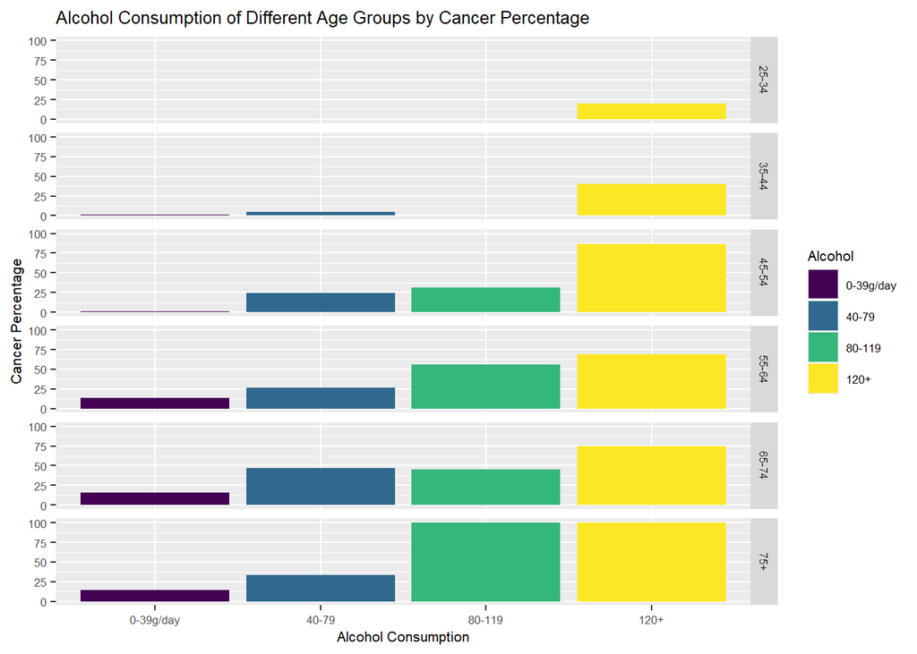

```r
grp_alc_age<-esoph%>% group_by(Age,Alcohol)%>% summarise(case_sum = sum(ncases), control_sum = sum(ncontrols),age_alc_perc=100*(case_sum/control_sum))
ggplot(grp_alc_age)+
  geom_bar(stat="identity",aes(Alcohol,age_alc_perc,fill=Alcohol))+
  facet_grid(Age ~.)+
  theme(text=element_text(size=8))+
  labs(title="Alcohol Consumption of Different Age Groups by Cancer Percentage",x="Alcohol Consumption",y="Cancer Percentage")
```

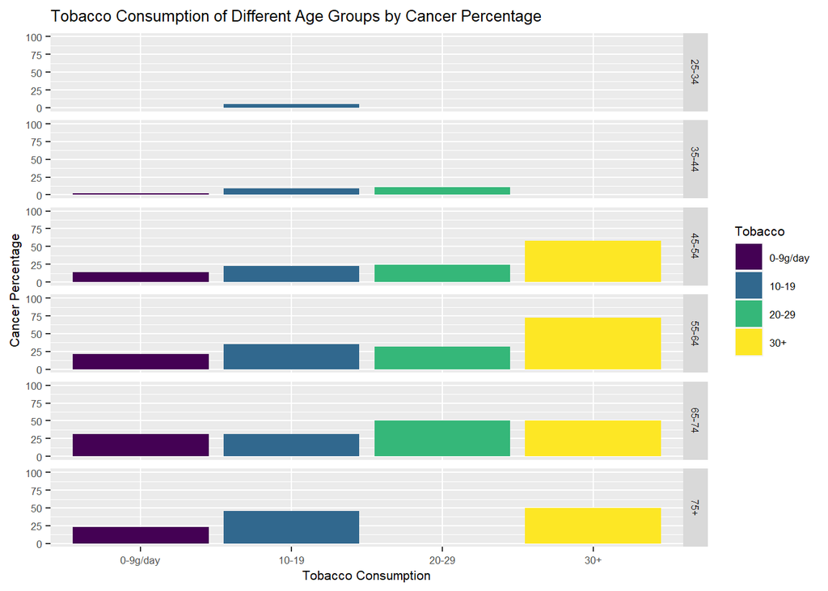

```r
grp_tob_age<-esoph%>% group_by(Age,Tobacco)%>% summarise(case_sum = sum(ncases), control_sum = sum(ncontrols),age_tob_perc=100*(case_sum/control_sum))
ggplot(grp_tob_age)+
  geom_bar(stat="identity",aes(Tobacco,age_tob_perc,fill=Tobacco))+
  facet_grid(Age ~.)+
  theme(text=element_text(size=8))+
  labs(title="Tobacco Consumption of Different Age Groups by Cancer Percentage",x="Tobacco Consumption",y="Cancer Percentage")+
  expand_limits(y = c(0, 100))
```

### The Linear Generalized Regression Model of the Data

```r
esoph<-esoph%>%
  mutate(cancer_perc= ncases/ncontrols)
relation_model<- glm(cancer_perc ~ Age+unclass(Alcohol)+unclass(Tobacco), data= esoph, family=quasibinomial)
summary(relation_model)
```

```
##
## Call:
## glm(formula = cancer_perc ~ Age + unclass(Alcohol) + unclass(Tobacco),
##     family = quasibinomial, data = esoph)
##
## Deviance Residuals:
##     Min       1Q   Median       3Q      Max
## -1.3707  -0.3486  -0.1154   0.2667   1.9445
##
## Coefficients:
##                  Estimate Std. Error t value Pr(>|t|)
## (Intercept)      -4.81276    0.63817  -7.541 6.36e-11 ***
## Age.L             3.61109    0.50011   7.221 2.67e-10 ***
## Age.Q            -0.73530    0.41787  -1.760   0.0823 .
## Age.C            -0.03952    0.41440  -0.095   0.9243
## Age^4             0.71956    0.39184   1.836   0.0700 .
## Age^5            -0.24470    0.33663  -0.727   0.4694
## unclass(Alcohol)  1.20615    0.16174   7.457 9.27e-11 ***
## unclass(Tobacco)  0.32713    0.13843   2.363   0.0205 *
## ---
## Signif. codes:  0 '***' 0.001 '**' 0.01 '*' 0.05 '.' 0.1 ' ' 1
##
## (Dispersion parameter for quasibinomial family taken to be 0.2676417)
##
##     Null deviance: 61.609  on 87  degrees of freedom
## Residual deviance: 22.465  on 80  degrees of freedom
## AIC: NA
##
## Number of Fisher Scoring iterations: 6
```

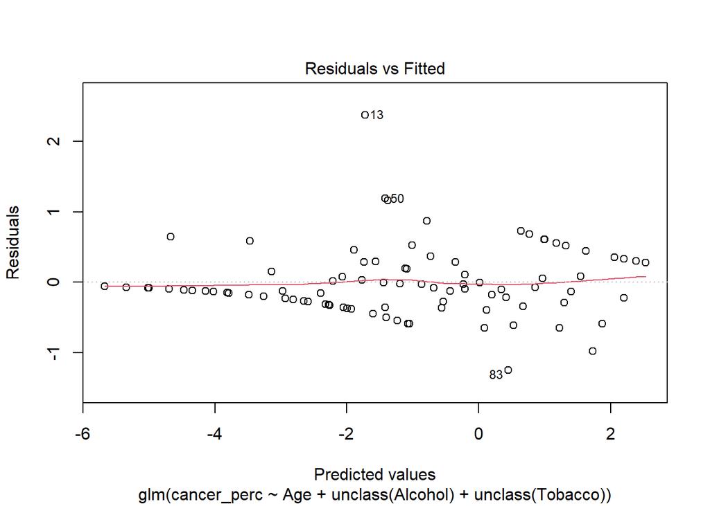

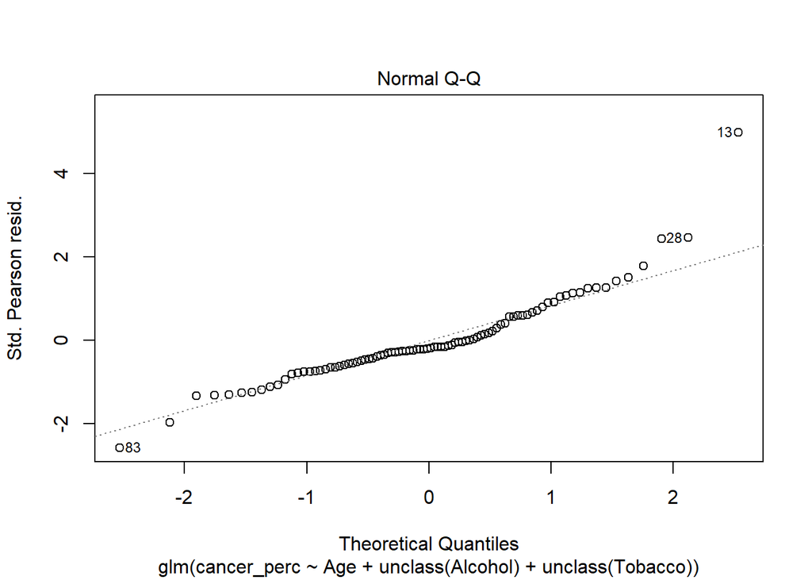

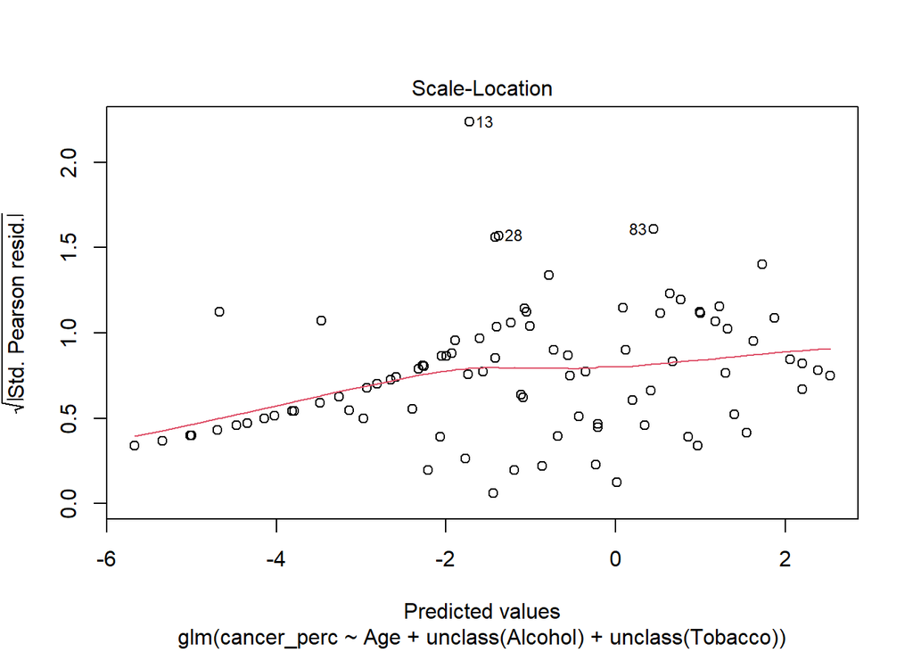

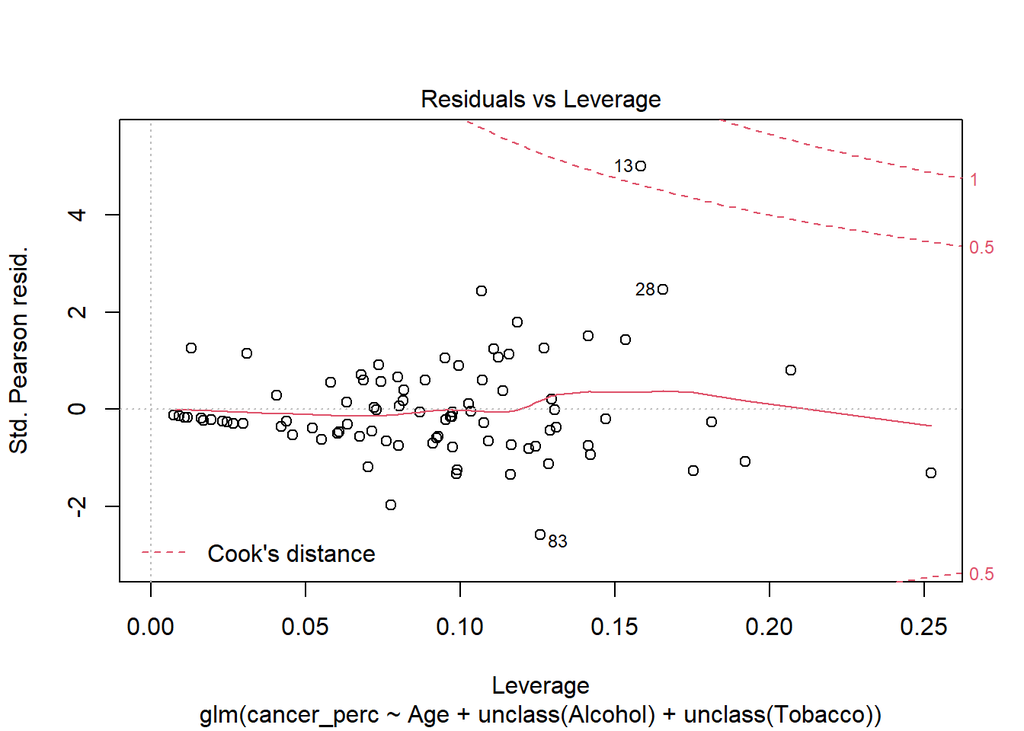

```r
plot(relation_model)
```

# The Young People Survey Data

In this part of the report, pca test and multidimensional scaling is going to be performed. Firstly, the data is read. Right after, the appropriate columns are selected and filtered to eliminate blank values. Lastly, it’s transformed into tibble format.

```r
responses<-read.csv("D:/wın/Documents/responses.csv",sep=",")
response_selected<- responses[,1:50] %>%
  filter(complete.cases(.))%>%
  tibble::as_tibble()
```

### PCA Test

PCA test is performed on the data and the result is plotted. From the graph, we can see the variance explained by components. The line shows that the first 10 components explains the variance by fifty percent. From the glimpse of the pca test, the effects of components can be examined separately between each other.

```r
pca<-
  response_selected[,sapply(response_selected,class)=="integer"]
pca_test<-princomp(pca,cor=T)
pca_test
```

```
## Call:
## princomp(x = pca, cor = T)
##
## Standard deviations:
##    Comp.1    Comp.2    Comp.3    Comp.4    Comp.5    Comp.6    Comp.7    Comp.8
## 2.3651766 2.0693471 1.8283193 1.5798756 1.5618969 1.4168315 1.2815478 1.2221441
##    Comp.9   Comp.10   Comp.11   Comp.12   Comp.13   Comp.14   Comp.15   Comp.16
## 1.1940377 1.1747227 1.0847612 1.0576569 1.0363761 0.9974747 0.9780845 0.9650321
##   Comp.17   Comp.18   Comp.19   Comp.20   Comp.21   Comp.22   Comp.23   Comp.24
## 0.9567624 0.9300856 0.9144844 0.8918774 0.8793752 0.8628713 0.8297417 0.8252889
##   Comp.25   Comp.26   Comp.27   Comp.28   Comp.29   Comp.30   Comp.31   Comp.32
## 0.8140050 0.8034753 0.7784630 0.7716408 0.7593681 0.7470054 0.7408130 0.7211042
##   Comp.33   Comp.34   Comp.35   Comp.36   Comp.37   Comp.38   Comp.39   Comp.40
## 0.7166999 0.6971306 0.6869232 0.6773965 0.6636276 0.6439094 0.6406987 0.6295626
##   Comp.41   Comp.42   Comp.43   Comp.44   Comp.45   Comp.46   Comp.47   Comp.48
## 0.6194463 0.5989862 0.5942076 0.5705103 0.5547907 0.5485424 0.5270643 0.5103355
##   Comp.49   Comp.50
## 0.5085176 0.4610274
##
##  50  variables and  849 observations.
```

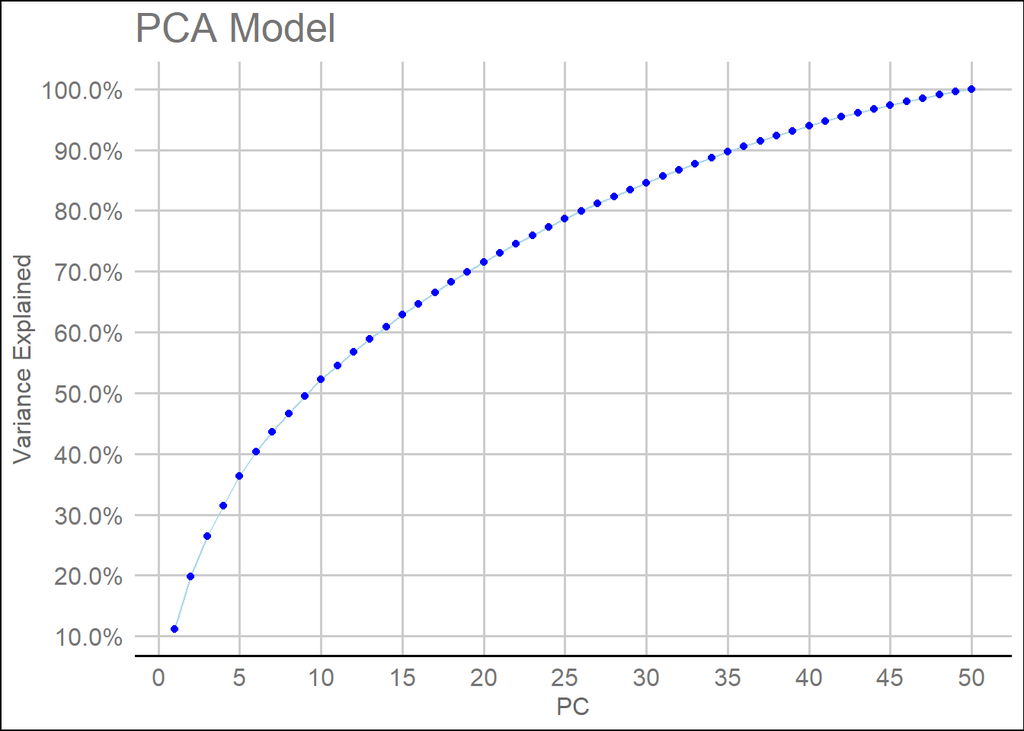

```r
ggplot(data=data.frame(PC=1:length(pca_test$sdev),var_exp=cumsum(pca_test$sdev^2/sum(pca_test$sdev^2))),
       aes(x=PC,y=var_exp)) + geom_line(color="lightblue") + geom_point(color="blue") + scale_y_continuous(labels = scales::percent,breaks=seq(0,1,length.out=11)) + scale_x_continuous(breaks=seq(0,135,by=5))+
  labs(title="PCA Model",y="Variance Explained")+
  theme_gdocs()
```

### Multidimensional Scaling

In this part of the report, mds method is going to be conducted, using the correlation between factors to draw similarities in the data. Firstly, set.seed function is used to create production and the appropriate adjustion in the data is made.

```r
set.seed(100)
mds <- 1 - cor(response_selected)
```

Multidimensional scaling is conducted and visualized below.

```r
mds_done <- cmdscale(mds,k=2)
colnames(mds_done) <- c("A","B")
print(mds_done)
```

```
##                                     A            B
## Music                     0.019388985 -0.148027531
## Slow.songs.or.fast.songs -0.303863133 -0.081012590
## Dance                    -0.238866628 -0.489622918
## Folk                      0.312640160  0.027987445
## Country                   0.088681368  0.104501866
## Classical.music           0.338921269  0.237068278
## Musical                   0.356722024 -0.225998009
## Pop                      -0.134465759 -0.594988802
## Rock                      0.145410437  0.282766104
## Metal.or.Hardrock         0.006072772  0.511595103
## Punk                      0.010207484  0.355198522
## Hiphop..Rap              -0.403495414 -0.407895326
## Reggae..Ska              -0.010885342 -0.036510594
## Swing..Jazz               0.313055193  0.090101387
## Rock.n.roll               0.220847265  0.188457822
## Alternative               0.242276200  0.320646614
## Latino                    0.239324362 -0.408370828
## Techno..Trance           -0.354734265 -0.218379533
## Opera                     0.316850067  0.180785021
## Movies                   -0.117395643 -0.151028047
## Horror                   -0.412945697  0.016899413
## Thriller                 -0.379903246  0.109315546
## Comedy                   -0.214983586 -0.403008824
## Romantic                  0.257142775 -0.543013630
## Sci.fi                   -0.302720365  0.212353252
## War                      -0.309877437  0.289895603
## Fantasy.Fairy.tales       0.283418078 -0.344686983
## Animated                  0.167315370 -0.237306852
## Documentary               0.078900911  0.236883959
## Western                  -0.203895889  0.297014391
## Action                   -0.496618234  0.097077118
## History                   0.073038520  0.270349622
## Psychology                0.236460416 -0.027479758
## Politics                 -0.118250835  0.219852065
## Mathematics              -0.182752267  0.137701336
## Physics                  -0.150505539  0.267646371
## Internet                 -0.396408250 -0.079997386
## PC                       -0.476315975  0.176778922
## Economy.Management       -0.263333276 -0.122196623
## Biology                   0.293107334 -0.132955929
## Chemistry                 0.186735612 -0.028458178
## Reading                   0.537168348  0.021709881
## Geography                 0.019834070  0.116358314
## Foreign.languages         0.226720678 -0.103713676
## Medicine                  0.265357630 -0.069515267
## Law                      -0.079750389  0.001581521
## Cars                     -0.550299749  0.035143847
## Art.exhibitions           0.409686211  0.053044369
## Religion                  0.236923938  0.063377610
## Countryside..outdoors     0.220059441 -0.067924017
```

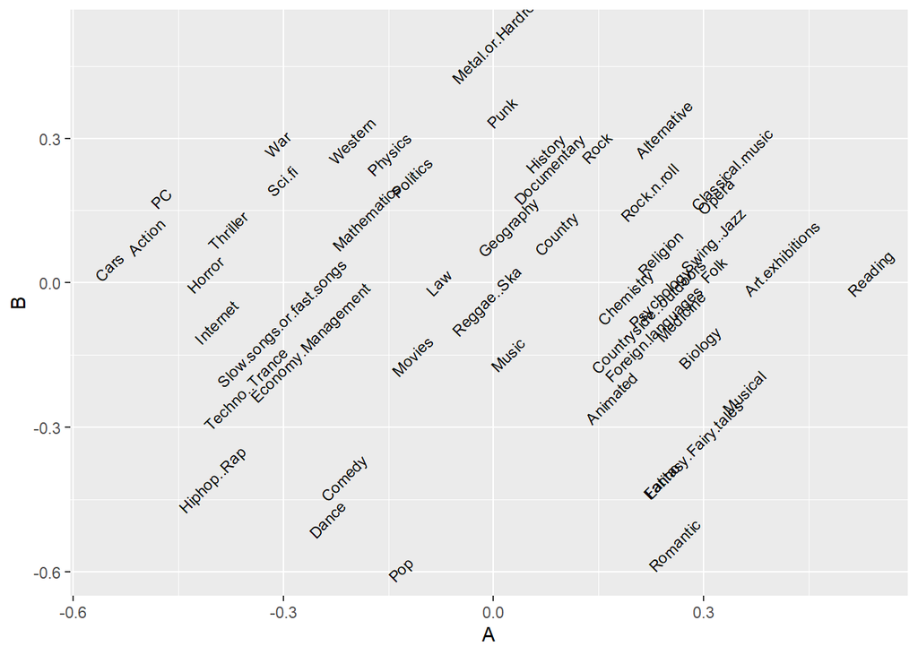

```r
ggplot(data.frame(mds_done),aes(x=A,y=B)) + geom_text(label=rownames(mds_done),angle=45,size=3)
```

Multidimensional scaling provided the insight on what young people prefer, and which ones are close in preference to one another. We have some interesting insights on the graph, the category latino and fairy tales are preferred in common! While reading and hiphop are far away from each other, personally I felt insecure about this insight, and Cars category is also irrelevant to Romance, as it should. With Multidimensional Scaling, every category’s relation with each other is crystal clear and easy to comment on.

# References

[IE48A Lecture Notes](https://mef-bda503.github.io/archive/fall17/files/intro_to_ml.html)

[STHDA](http://www.sthda.com/english/wiki/correlation-test-between-two-variables-in-r)